# Regression Model for Metro Interstate Traffic Volume Using R Take 1

David Lowe

August 19, 2019

Template Credit: Adapted from a template made available by Dr. Jason Brownlee of Machine Learning Mastery. [http://machinelearningmastery.com/]

SUMMARY: The purpose of this project is to construct a predictive model using various machine learning algorithms and to document the end-to-end steps using a template. The Metro Interstate Traffic Volume is a regression situation where we are trying to predict a real-number value for a given set of criteria.

INTRODUCTION: This dataset captured the hourly measurement of Interstate 94 Westbound traffic volume for MN DoT ATR station 301. The station is roughly midway between Minneapolis and St Paul, MN. The dataset also included the hourly weather and holiday attributes for assessing their impacts on traffic volume.

In this iteration, we will establish the baseline mean squared error for comparison with future rounds of modeling. This round of modeling will not include the date-time attribute.

Dataset Used: Metro Interstate Traffic Volume Data Set

Dataset ML Model: Regression with numerical and categorical attributes

Dataset Reference: https://archive.ics.uci.edu/ml/datasets/Metro+Interstate+Traffic+Volume

One potential source of performance benchmarks: https://www.kaggle.com/ramyahr/metro-interstate-traffic-volume

The project aims to touch on the following areas:

1. Document a predictive modeling problem end-to-end.
2. Explore data cleaning and transformation options
3. Explore non-ensemble and ensemble algorithms for baseline model performance
4. Explore algorithm tuning techniques for improving model performance

Any predictive modeling machine learning project genrally can be broken down into about six major tasks:

1. Prepare Environment
2. Summarize Data
3. Prepare Data
4. Model and Evaluate Algorithms
5. Improve Accuracy or Results
6. Finalize Model and Present Results

## 1. Prepare Environment

### 1.a) Load libraries and packages

```r
startTimeScript <- proc.time()
library(caret)
```

```r
library(corrplot)
library(DMwR)
library(Hmisc)
library(ROCR)
library(stringr)
```

### 1.b) Set up the controlling parameters and functions

```r
# Create the random seed number for reproducible results
seedNum <- 888

# Set up the notifyStatus flag to stop sending progress emails (setting to TRUE will send status emails!)
notifyStatus <- TRUE
if (notifyStatus) library(mailR)
# Run algorithms using 10-fold cross validation
control <- trainControl(method="repeatedcv", number=10, repeats=1)
metricTarget <- "RMSE"
```

```r
# Set up the email notification function
email_notify <- function(msg=""){
  sender <- Sys.getenv("MAIL_SENDER")
  receiver <- Sys.getenv("MAIL_RECEIVER")
  gateway <- Sys.getenv("SMTP_GATEWAY")
  smtpuser <- Sys.getenv("SMTP_USERNAME")
  password <- Sys.getenv("SMTP_PASSWORD")
  sbj_line <- "Notification from R Binary Classification Script"
  send.mail(
    from = sender,
    to = receiver,
    subject= sbj_line,
    body = msg,
    smtp = list(host.name = gateway, port = 587, user.name = smtpuser, passwd = password, ssl = TRUE),
    authenticate = TRUE,
    send = TRUE)
}
```

```r
if (notifyStatus) email_notify(paste("Library and Data Loading has begun!",date()))
```

```
## [1] "Java-Object{org.apache.commons.mail.SimpleEmail@3b6eb2ec}"
```

### 1.c) Load dataset

```r
# Slicing up the document path to get the final destination file name
dataset_path <- 'https://archive.ics.uci.edu/ml/machine-learning-databases/00492/Metro_Interstate_Traffic_Volume.csv.gz'
doc_path_list <- str_split(dataset_path, "/")
# dest_file <- doc_path_list[[1]][length(doc_path_list[[1]])]
dest_file <- "Metro_Interstate_Traffic_Volume.csv"

if (!file.exists(dest_file)) {
  # Download the document from the website
  cat("Downloading", dataset_path, "as", dest_file, "\n")
  download.file(dataset_path, dest_file, mode = "wb")
  cat(dest_file, "downloaded!\n")
  unzip(dest_file)
  cat(dest_file, "unpacked!\n")
}

inputFile <- dest_file
Xy_original <- read.csv(dest_file, header = TRUE)
```

```r
# Take a peek at the dataframe after the import
head(Xy_original)
```

```
##   holiday   temp rain_1h snow_1h clouds_all weather_main
## 1    None 288.28       0       0         40       Clouds
## 2    None 289.36       0       0         75       Clouds
## 3    None 289.58       0       0         90       Clouds
## 4    None 290.13       0       0         90       Clouds
## 5    None 291.14       0       0         75       Clouds
## 6    None 291.72       0       0          1        Clear
##   weather_description           date_time traffic_volume
## 1    scattered clouds 2012-10-02 09:00:00           5545
## 2       broken clouds 2012-10-02 10:00:00           4516
## 3     overcast clouds 2012-10-02 11:00:00           4767
## 4     overcast clouds 2012-10-02 12:00:00           5026
## 5       broken clouds 2012-10-02 13:00:00           4918
## 6        sky is clear 2012-10-02 14:00:00           5181
```

```r
sapply(Xy_original, class)
```

```
##             holiday                temp             rain_1h
##            "factor"           "numeric"           "numeric"
##             snow_1h          clouds_all        weather_main
##           "numeric"           "integer"            "factor"
## weather_description           date_time      traffic_volume
##            "factor"            "factor"           "integer"
```

```r
sapply(Xy_original, function(x) sum(is.na(x)))
```

```
##             holiday                temp             rain_1h
##                   0                   0                   0
##             snow_1h          clouds_all        weather_main
##                   0                   0                   0
## weather_description           date_time      traffic_volume
##                   0                   0                   0
```

### 1.d) Data Cleaning

```r
# Dropping features
Xy_original$date_time <- NULL
Xy_original$weather_description <- NULL
```

```r
# Take a peek at the dataframe after the cleaning
head(Xy_original)
```

```
##   holiday   temp rain_1h snow_1h clouds_all weather_main traffic_volume
## 1    None 288.28       0       0         40       Clouds           5545
## 2    None 289.36       0       0         75       Clouds           4516
## 3    None 289.58       0       0         90       Clouds           4767
## 4    None 290.13       0       0         90       Clouds           5026
## 5    None 291.14       0       0         75       Clouds           4918
## 6    None 291.72       0       0          1        Clear           5181
```

```r
sapply(Xy_original, class)
```

```
##        holiday           temp        rain_1h        snow_1h     clouds_all
##       "factor"      "numeric"      "numeric"      "numeric"      "integer"
##   weather_main traffic_volume
##       "factor"      "integer"
```

```r
sapply(Xy_original, function(x) sum(is.na(x)))
```

```
##        holiday           temp        rain_1h        snow_1h     clouds_all
##              0              0              0              0              0
##   weather_main traffic_volume
##              0              0
```

### 1.e) Splitting Data into Training and Test Sets

```r
# Use variable totCol to hold the number of columns in the dataframe
totCol <- ncol(Xy_original)

# Set up variable totAttr for the total number of attribute columns
totAttr <- totCol-1
```

```r
# targetCol variable indicates the column location of the target/class variable
# If the first column, set targetCol to 1. If the last column, set targetCol to totCol
# if (targetCol <> 1) and (targetCol <> totCol), be aware when slicing up the dataframes for visualization!
targetCol <- totCol

# Standardize the class column to the name of targetVar if applicable
colnames(Xy_original)[targetCol] <- "targetVar"
```

```r
# Create various sub-datasets for visualization and cleaning/transformation operations.
set.seed(seedNum)

# Use 75% of the data to train the models and the remaining for testing/validation
training_index <- createDataPartition(Xy_original$targetVar, p=0.75, list=FALSE)
Xy_train <- Xy_original[training_index,]
Xy_test <- Xy_original[-training_index,]

if (targetCol==1) {
  X_train <- Xy_train[,(targetCol+1):totCol]
  y_train <- Xy_train[,targetCol]
  y_test <- Xy_test[,targetCol]
} else {
  X_train <- Xy_train[,1:(totAttr)]
  y_train <- Xy_train[,totCol]
  y_test <- Xy_test[,totCol]
}
```

### 1.f) Set up the parameters for data visualization

```r
# Set up the number of row and columns for visualization display. dispRow * dispCol should be >= totAttr
dispCol <- 4
if (totAttr%%dispCol == 0) {
dispRow <- totAttr%/%dispCol
} else {
dispRow <- (totAttr%/%dispCol) + 1
}
cat("Will attempt to create graphics grid (col x row): ", dispCol, ' by ', dispRow)
```

```
## Will attempt to create graphics grid (col x row):  4  by  2
```

```r
if (notifyStatus) email_notify(paste("Library and Data Loading completed!",date()))
```

```
## [1] "Java-Object{org.apache.commons.mail.SimpleEmail@30c7da1e}"
```

## 2. Summarize Data

To gain a better understanding of the data that we have on-hand, we will leverage a number of descriptive statistics and data visualization techniques. The plan is to use the results to consider new questions, review assumptions, and validate hypotheses that we can investigate later with specialized models.

```r
if (notifyStatus) email_notify(paste("Data Summarization and Visualization has begun!",date()))
```

```
## [1] "Java-Object{org.apache.commons.mail.SimpleEmail@2812cbfa}"
```

### 2.a) Descriptive statistics

#### 2.a.i) Peek at the data itself

```r
head(Xy_train)
```

```
##    holiday   temp rain_1h snow_1h clouds_all weather_main targetVar
## 2     None 289.36       0       0         75       Clouds      4516
## 3     None 289.58       0       0         90       Clouds      4767
## 4     None 290.13       0       0         90       Clouds      5026
## 5     None 291.14       0       0         75       Clouds      4918
## 8     None 293.86       0       0          1        Clear      6015
## 11    None 290.97       0       0         20       Clouds      3539
```

#### 2.a.ii) Dimensions of the dataset

```r
dim(Xy_train)
```

```
## [1] 36154     7
```

#### 2.a.iii) Types of the attribute

```r
sapply(Xy_train, class)
```

```
##      holiday         temp      rain_1h      snow_1h   clouds_all
##     "factor"    "numeric"    "numeric"    "numeric"    "integer"
## weather_main    targetVar
##     "factor"    "integer"
```

#### 2.a.iv) Statistical summary of the attributes

```r
summary(Xy_train)
```

```
##                       holiday           temp          rain_1h
##  None                     :36104   Min.   :  0.0   Min.   :   0.000
##  Labor Day                :    7   1st Qu.:272.1   1st Qu.:   0.000
##  Christmas Day            :    5   Median :282.6   Median :   0.000
##  Columbus Day             :    5   Mean   :281.2   Mean   :   0.402
##  Martin Luther King Jr Day:    5   3rd Qu.:291.8   3rd Qu.:   0.000
##  Thanksgiving Day         :    5   Max.   :310.1   Max.   :9831.300
##  (Other)                  :   23
##     snow_1h            clouds_all      weather_main     targetVar
##  Min.   :0.0000000   Min.   :  0.00   Clouds :11422   Min.   :   0
##  1st Qu.:0.0000000   1st Qu.:  1.00   Clear  : 9975   1st Qu.:1193
##  Median :0.0000000   Median : 64.00   Mist   : 4485   Median :3380
##  Mean   :0.0001895   Mean   : 49.43   Rain   : 4249   Mean   :3259
##  3rd Qu.:0.0000000   3rd Qu.: 90.00   Snow   : 2176   3rd Qu.:4933
##  Max.   :0.5100000   Max.   :100.00   Drizzle: 1349   Max.   :7280
##                                       (Other): 2498
```

#### 2.a.v) Count missing values

```r
sapply(Xy_train, function(x) sum(is.na(x)))
```

```
##      holiday         temp      rain_1h      snow_1h   clouds_all
##            0            0            0            0            0
## weather_main    targetVar
##            0            0
```

### 2.b) Data visualizations

```r
# Boxplots for each attribute
# par(mfrow=c(dispRow,dispCol))
# for(i in 1:totAttr) {
#   boxplot(X_train[,i], main=names(X_train)[i])
# }
```

```r
# Histograms each attribute
# par(mfrow=c(dispRow,dispCol))
# for(i in 1:totAttr) {
#   hist(X_train[,i], main=names(X_train)[i])
# }
```

```r
# Density plot for each attribute
# par(mfrow=c(dispRow,dispCol))
# for(i in 1:totAttr) {
#   plot(density(X_train[,i]), main=names(X_train)[i])
# }
```

```r
# Correlation matrix
# correlations <- cor(X_train)
# corrplot(correlations, method="circle")
```

```r
if (notifyStatus) email_notify(paste("Data Summarization and Visualization completed!",date()))
```

```
## [1] "Java-Object{org.apache.commons.mail.SimpleEmail@2f7a2457}"
```

## 3. Prepare Data

Some dataset may require additional preparation activities that will best exposes the structure of the problem and the relationships between the input attributes and the output variable. Some data-prep tasks might include:

- Cleaning data by removing duplicates, marking missing values and even imputing missing values.
- Feature selection where redundant features may be removed.
- Data transforms where attributes are scaled or redistributed in order to best expose the structure of the problem later to learning algorithms.

```r
if (notifyStatus) email_notify(paste("Data Cleaning and Transformation has begun!",date()))
```

```
## [1] "Java-Object{org.apache.commons.mail.SimpleEmail@5ebec15}"
```

### 3.a) Data Transforms

```r
# Not applicable for this iteration of the project
```

### 3.b) Feature Selection

```r
# Not applicable for this iteration of the project
```

### 3.c) Display the Final Datasets for Model-Building

```r
# We finalize the training and testing datasets for the modeling activities
dim(Xy_train)
```

```
## [1] 36154     7
```

```r
dim(Xy_test)
```

```
## [1] 12050     7
```

```r
if (notifyStatus) email_notify(paste("Data Cleaning and Transformation completed!",date()))
```

```
## [1] "Java-Object{org.apache.commons.mail.SimpleEmail@38082d64}"
```

```r
proc.time()-startTimeScript
```

```
##    user  system elapsed
##   5.952   0.583  15.893
```

## 4. Model and Evaluate Algorithms

After the data-prep, we next work on finding a workable model by evaluating a subset of machine learning algorithms that are good at exploiting the structure of the dataset. The typical evaluation tasks include:

- Defining test options such as cross validation and the evaluation metric to use.
- Spot checking a suite of linear and nonlinear machine learning algorithms.
- Comparing the estimated accuracy of algorithms.

For this project, we will evaluate four linear, one non-linear, and three ensemble algorithms:

Linear Algorithms: Linear Regression, Ridge, The Lasso, Elasticnet

Non-Linear Algorithm: Decision Trees (CART)

Ensemble Algorithms: Bagged CART, Random Forest, and Gradient Boosting

The random number seed is reset before each run to ensure that the evaluation of each algorithm is performed using the same data splits. It ensures the results are directly comparable.

### 4.a) Generate models using linear algorithms

```r
startModeling <- proc.time()
```

```r
# Linear Regression (Regression)
if (notifyStatus) email_notify(paste("Linear Regression modeling has begun!",date()))
```

```
## [1] "Java-Object{org.apache.commons.mail.SimpleEmail@180bc464}"
```

```r
startTimeModule <- proc.time()
set.seed(seedNum)
fit.lm <- train(targetVar~., data=Xy_train, method="lm", metric=metricTarget, trControl=control)
print(fit.lm)
```

```
## Linear Regression
##
## 36154 samples
##     6 predictor
##
## No pre-processing
## Resampling: Cross-Validated (10 fold, repeated 1 times)
## Summary of sample sizes: 32539, 32539, 32539, 32539, 32538, 32538, ...
## Resampling results:
##
##   RMSE      Rsquared   MAE
##   2605.025  0.0384868  1700.904
##
## Tuning parameter 'intercept' was held constant at a value of TRUE
```

```r
proc.time()-startTimeModule
```

```
##    user  system elapsed
##   4.222   1.341   3.915
```

```r
if (notifyStatus) email_notify(paste("Linear Regression modeling completed!",date()))
```

```
## [1] "Java-Object{org.apache.commons.mail.SimpleEmail@2d554825}"
```

```r
# Ridge (Regression)
if (notifyStatus) email_notify(paste("Ridge Regression modeling has begun!",date()))
```

```
## [1] "Java-Object{org.apache.commons.mail.SimpleEmail@4909b8da}"
```

```r
startTimeModule <- proc.time()
set.seed(seedNum)
fit.ridge <- train(targetVar~., data=Xy_train, method="ridge", metric=metricTarget, trControl=control)
print(fit.ridge)
```

```
## Ridge Regression
##
## 36154 samples
##     6 predictor
##
## No pre-processing
## Resampling: Cross-Validated (10 fold, repeated 1 times)
## Summary of sample sizes: 32539, 32539, 32539, 32539, 32538, 32538, ...
## Resampling results across tuning parameters:
##
##   lambda  RMSE      Rsquared    MAE
##   0e+00   2605.025  0.03848680  1700.904
##   1e-04   2605.037  0.03848683  1700.904
##   1e-01   2609.565  0.03834520  1701.272
##
## RMSE was used to select the optimal model using the smallest value.
## The final value used for the model was lambda = 0.
```

```r
proc.time()-startTimeModule
```

```
##    user  system elapsed
##  17.529  11.550  15.849
```

```r
if (notifyStatus) email_notify(paste("Ridge Regression modeling completed!",date()))
```

```
## [1] "Java-Object{org.apache.commons.mail.SimpleEmail@54a097cc}"
```

```r
# The Lasso (Regression)
if (notifyStatus) email_notify(paste("The Lasso modeling has begun!",date()))
```

```
## [1] "Java-Object{org.apache.commons.mail.SimpleEmail@50f8360d}"
```

```r
startTimeModule <- proc.time()
set.seed(seedNum)
fit.lasso <- train(targetVar~., data=Xy_train, method="lasso", metric=metricTarget, trControl=control)
print(fit.lasso)
```

```
## The lasso
##
## 36154 samples
##     6 predictor
##
## No pre-processing
## Resampling: Cross-Validated (10 fold, repeated 1 times)
## Summary of sample sizes: 32539, 32539, 32539, 32539, 32538, 32538, ...
## Resampling results across tuning parameters:
##
##   fraction  RMSE      Rsquared    MAE
##   0.1       1972.016  0.03172163  1730.768
##   0.5       2032.252  0.03654999  1702.395
##   0.9       2571.155  0.03846129  1701.116
##
## RMSE was used to select the optimal model using the smallest value.
## The final value used for the model was fraction = 0.1.
```

```r
proc.time()-startTimeModule
```

```
##    user  system elapsed
##   6.698   3.864   5.941
```

```r
if (notifyStatus) email_notify(paste("The Lasso modeling completed!",date()))
```

```
## [1] "Java-Object{org.apache.commons.mail.SimpleEmail@337d0578}"
```

```r
# Elasticnet (Regression)
if (notifyStatus) email_notify(paste("Elasticnet modeling has begun!",date()))
```

```
## [1] "Java-Object{org.apache.commons.mail.SimpleEmail@2669b199}"
```

```r
startTimeModule <- proc.time()
set.seed(seedNum)
fit.enet <- train(targetVar~., data=Xy_train, method="enet", metric=metricTarget, trControl=control)
print(fit.enet)
```

```
## Elasticnet
##
## 36154 samples
##     6 predictor
##
## No pre-processing
## Resampling: Cross-Validated (10 fold, repeated 1 times)
## Summary of sample sizes: 32539, 32539, 32539, 32539, 32538, 32538, ...
## Resampling results across tuning parameters:
##
##   lambda  fraction  RMSE      Rsquared    MAE
##   0e+00   0.050     1978.602  0.03022420  1737.513
##   0e+00   0.525     2073.883  0.03690230  1702.125
##   0e+00   1.000     2605.025  0.03848680  1700.904
##   1e-04   0.050     1978.603  0.03022391  1737.513
##   1e-04   0.525     2073.833  0.03690172  1702.126
##   1e-04   1.000     2605.037  0.03848683  1700.904
##   1e-01   0.050     1978.876  0.03007894  1737.784
##   1e-01   0.525     2032.914  0.03654976  1702.096
##   1e-01   1.000     2609.565  0.03834520  1701.272
##
## RMSE was used to select the optimal model using the smallest value.
## The final values used for the model were fraction = 0.05 and lambda = 0.
```

```r
proc.time()-startTimeModule
```

```
##    user  system elapsed
##  16.783  10.440  14.703
```

```r
if (notifyStatus) email_notify(paste("Elasticnet modeling completed!",date()))
```

```
## [1] "Java-Object{org.apache.commons.mail.SimpleEmail@3c756e4d}"
```

### 4.b) Generate models using nonlinear algorithms

```r
# Decision Tree - CART (Regression/Classification)
if (notifyStatus) email_notify(paste("Decision Tree modeling has begun!",date()))
```

```
## [1] "Java-Object{org.apache.commons.mail.SimpleEmail@4439f31e}"
```

```r
startTimeModule <- proc.time()
set.seed(seedNum)
fit.cart <- train(targetVar~., data=Xy_train, method="rpart", metric=metricTarget, trControl=control)
print(fit.cart)
```

```
## CART
##
## 36154 samples
##     6 predictor
##
## No pre-processing
## Resampling: Cross-Validated (10 fold, repeated 1 times)
## Summary of sample sizes: 32539, 32539, 32539, 32539, 32538, 32538, ...
## Resampling results across tuning parameters:
##
##   cp           RMSE      Rsquared    MAE
##   0.005221101  1937.605  0.04833976  1683.157
##   0.021243113  1950.173  0.03596580  1699.244
##   0.027971321  1974.015  0.02432496  1729.023
##
## RMSE was used to select the optimal model using the smallest value.
## The final value used for the model was cp = 0.005221101.
```

```r
proc.time()-startTimeModule
```

```
##    user  system elapsed
##   7.557   2.577   8.964
```

```r
if (notifyStatus) email_notify(paste("Decision Tree modeling completed!",date()))
```

```
## [1] "Java-Object{org.apache.commons.mail.SimpleEmail@2a2d45ba}"
```

### 4.c) Generate models using ensemble algorithms

In this section, we will explore the use and tuning of ensemble algorithms to see whether we can improve the results.

```r
# Bagged CART (Regression/Classification)
if (notifyStatus) email_notify(paste("Bagged CART modeling has begun!",date()))
```

```
## [1] "Java-Object{org.apache.commons.mail.SimpleEmail@457e2f02}"
```

```r
startTimeModule <- proc.time()
set.seed(seedNum)
fit.bagcart <- train(targetVar~., data=Xy_train, method="treebag", metric=metricTarget, trControl=control)
print(fit.bagcart)
```

```
## Bagged CART
##
## 36154 samples
##     6 predictor
##
## No pre-processing
## Resampling: Cross-Validated (10 fold, repeated 1 times)
## Summary of sample sizes: 32539, 32539, 32539, 32539, 32538, 32538, ...
## Resampling results:
##
##   RMSE      Rsquared    MAE
##   1934.851  0.05112062  1681.86
```

```r
proc.time()-startTimeModule
```

```
##    user  system elapsed
##  85.647  24.495  80.909
```

```r
if (notifyStatus) email_notify(paste("Bagged CART modeling completed!",date()))
```

```
## [1] "Java-Object{org.apache.commons.mail.SimpleEmail@cb5822}"
```

```r
# Random Forest (Regression/Classification)
if (notifyStatus) email_notify(paste("Random Forest modeling has begun!",date()))
```

```
## [1] "Java-Object{org.apache.commons.mail.SimpleEmail@28d25987}"
```

```r
startTimeModule <- proc.time()
set.seed(seedNum)
fit.rf <- train(targetVar~., data=Xy_train, method="rf", metric=metricTarget, trControl=control)
print(fit.rf)
```

```
## Random Forest
##
## 36154 samples
##     6 predictor
##
## No pre-processing
## Resampling: Cross-Validated (10 fold, repeated 1 times)
## Summary of sample sizes: 32539, 32539, 32539, 32539, 32538, 32538, ...
## Resampling results across tuning parameters:
##
##   mtry  RMSE      Rsquared    MAE
##    2    1936.576  0.06541641  1691.427
##   13    1873.962  0.10996980  1602.826
##   25    2020.296  0.07144432  1643.442
##
## RMSE was used to select the optimal model using the smallest value.
## The final value used for the model was mtry = 13.
```

```r
proc.time()-startTimeModule
```

```
##      user    system   elapsed
## 24822.294     9.312 24892.087
```

```r
if (notifyStatus) email_notify(paste("Random Forest modeling completed!",date()))
```

```
## [1] "Java-Object{org.apache.commons.mail.SimpleEmail@59f99ea}"
```

```r
# Gradient Boosting (Regression/Classification)
if (notifyStatus) email_notify(paste("Gradient Boosting modeling has begun!",date()))
```

```
## [1] "Java-Object{org.apache.commons.mail.SimpleEmail@5c3bd550}"
```

```r
startTimeModule <- proc.time()
set.seed(seedNum)
fit.gbm <- train(targetVar~., data=Xy_train, method="xgbTree", metric=metricTarget, trControl=control, verbose=F)
# fit.gbm <- train(targetVar~., data=Xy_train, method="gbm", metric=metricTarget, trControl=control, verbose=F)
print(fit.gbm)
```

```
## eXtreme Gradient Boosting
##
## 36154 samples
##     6 predictor
##
## No pre-processing
## Resampling: Cross-Validated (10 fold, repeated 1 times)
## Summary of sample sizes: 32539, 32539, 32539, 32539, 32538, 32538, ...
## Resampling results across tuning parameters:
##
##   eta  max_depth  colsample_bytree  subsample  nrounds  RMSE
##   0.3  1          0.6               0.50        50      1919.257
##   0.3  1          0.6               0.50       100      1916.771
##   0.3  1          0.6               0.50       150      1915.036
##   0.3  1          0.6               0.75        50      1919.257
##   0.3  1          0.6               0.75       100      1916.924
##   0.3  1          0.6               0.75       150      1915.134
##   0.3  1          0.6               1.00        50      1920.093
##   0.3  1          0.6               1.00       100      1917.646
##   0.3  1          0.6               1.00       150      1916.036
##   0.3  1          0.8               0.50        50      1919.187
##   0.3  1          0.8               0.50       100      1916.366
##   0.3  1          0.8               0.50       150      1914.909
##   0.3  1          0.8               0.75        50      1919.548
##   0.3  1          0.8               0.75       100      1916.660
##   0.3  1          0.8               0.75       150      1915.183
##   0.3  1          0.8               1.00        50      1919.990
##   0.3  1          0.8               1.00       100      1917.490
##   0.3  1          0.8               1.00       150      1915.928
##   0.3  2          0.6               0.50        50      1908.946
##   0.3  2          0.6               0.50       100      1904.258
##   0.3  2          0.6               0.50       150      1903.009
##   0.3  2          0.6               0.75        50      1907.878
##   0.3  2          0.6               0.75       100      1903.937
##   0.3  2          0.6               0.75       150      1901.692
##   0.3  2          0.6               1.00        50      1907.905
##   0.3  2          0.6               1.00       100      1902.892
##   0.3  2          0.6               1.00       150      1900.073
##   0.3  2          0.8               0.50        50      1907.815
##   0.3  2          0.8               0.50       100      1903.659
```

[output cut: 181 more lines]

```
##   0.08409875  1631.447
##   0.08609422  1638.221
##   0.09099373  1628.458
##   0.09293761  1623.430
##   0.08558202  1639.416
##   0.08995441  1630.545
##   0.09251052  1625.556
##
## Tuning parameter 'gamma' was held constant at a value of 0
##
## Tuning parameter 'min_child_weight' was held constant at a value of 1
## RMSE was used to select the optimal model using the smallest value.
## The final values used for the model were nrounds = 150, max_depth = 3,
##  eta = 0.4, gamma = 0, colsample_bytree = 0.8, min_child_weight = 1
##  and subsample = 0.75.
```

```r
proc.time()-startTimeModule
```

```
##     user   system  elapsed
## 1075.224    4.564  560.474
```

```r
if (notifyStatus) email_notify(paste("Gradient Boosting modeling completed!",date()))
```

```
## [1] "Java-Object{org.apache.commons.mail.SimpleEmail@39c0f4a}"
```

### 4.d) Compare baseline algorithms

```r
results <- resamples(list(LR=fit.lm, RIDGE=fit.ridge, LASSO=fit.lasso, ENET=fit.enet, CART=fit.cart, BagCART=fit.bagcart, RF=fit.rf, GBM=fit.gbm))
summary(results)
```

```
##
## Call:
## summary.resamples(object = results)
##
## Models: LR, RIDGE, LASSO, ENET, CART, BagCART, RF, GBM
## Number of resamples: 10
##
## MAE
##             Min.  1st Qu.   Median     Mean  3rd Qu.     Max. NA's
## LR      1669.040 1684.514 1687.599 1700.904 1691.189 1839.499    0
## RIDGE   1669.040 1684.514 1687.599 1700.904 1691.189 1839.499    0
## LASSO   1713.159 1727.498 1730.707 1730.768 1736.630 1745.467    0
## ENET    1718.999 1733.825 1737.589 1737.513 1742.838 1753.110    0
## CART    1665.546 1679.770 1684.344 1683.157 1689.280 1701.953    0
## BagCART 1663.993 1679.308 1681.710 1681.860 1686.121 1700.635    0
## RF      1590.154 1599.583 1600.325 1602.826 1603.757 1619.801    0
## GBM     1610.412 1619.588 1621.452 1623.430 1628.993 1639.926    0
##
## RMSE
##             Min.  1st Qu.   Median     Mean  3rd Qu.     Max. NA's
## LR      1924.024 1941.290 1945.204 2605.025 1946.918 8570.605    0
## RIDGE   1924.024 1941.290 1945.204 2605.025 1946.918 8570.605    0
## LASSO   1962.109 1968.336 1973.211 1972.016 1975.218 1982.361    0
## ENET    1968.463 1974.236 1979.790 1978.602 1981.945 1989.272    0
## CART    1921.091 1936.007 1938.707 1937.605 1939.804 1956.674    0
## BagCART 1922.122 1932.453 1936.152 1934.851 1936.668 1954.758    0
## RF      1859.952 1869.729 1872.641 1873.962 1875.255 1891.808    0
## GBM     1884.198 1887.005 1889.453 1892.209 1895.042 1906.463    0
##
## Rsquared
##                 Min.    1st Qu.     Median       Mean    3rd Qu.
## LR      5.677724e-05 0.03675753 0.04137765 0.03848680 0.04600577
## RIDGE   5.677724e-05 0.03675753 0.04137765 0.03848680 0.04600577
## LASSO   2.608205e-02 0.02770697 0.03038013 0.03172163 0.03500520
## ENET    2.124333e-02 0.02799291 0.02854977 0.03022420 0.03434020
## CART    4.085622e-02 0.04507732 0.04881462 0.04833976 0.05082780
## BagCART 4.253493e-02 0.04759156 0.05205611 0.05112062 0.05460160
## RF      8.957157e-02 0.10580215 0.11156461 0.10996980 0.11335849
## GBM     7.808661e-02 0.08896682 0.09388701 0.09293761 0.09872888
##               Max. NA's
## LR      0.05442038    0
## RIDGE   0.05442038    0
## LASSO   0.04096963    0
## ENET    0.03922094    0
## CART    0.05643103    0
## BagCART 0.05733570    0
## RF      0.12371854    0
## GBM     0.10244301    0
```

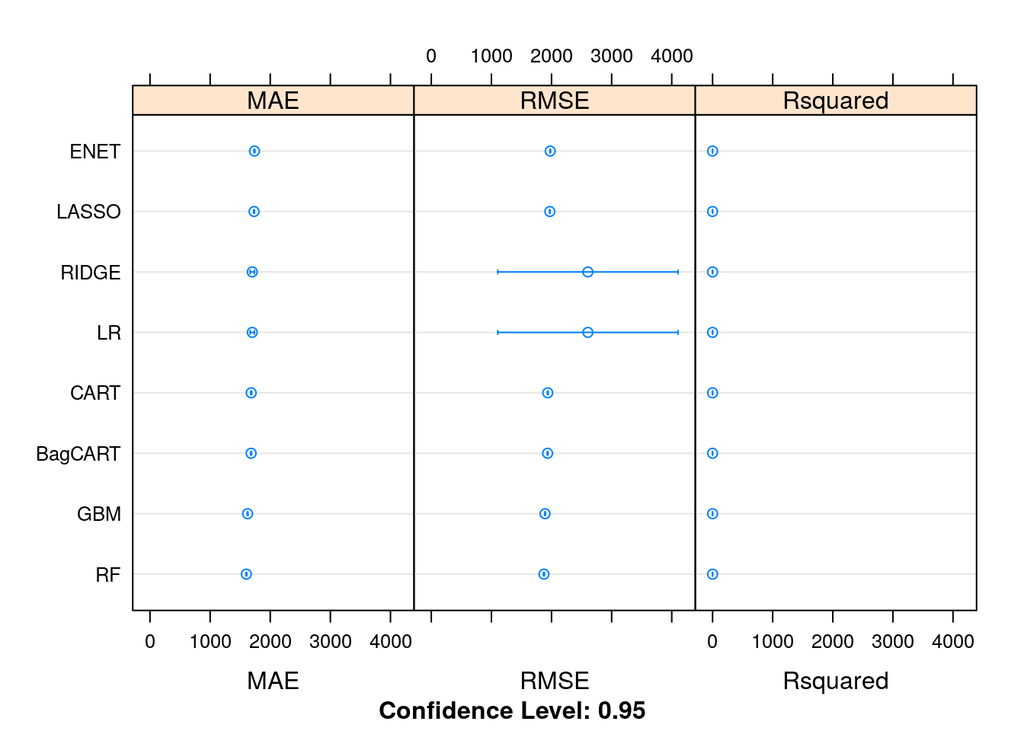

```r
dotplot(results)
```

```r
cat('The average RMSE from all models is:',
    mean(c(results$values$`LR~RMSE`,results$values$`RIDGE~RMSE`,results$values$`LASSO~RMSE`,results$values$`ENET~RMSE`,results$values$`CART~RMSE`,results$values$`BagCART~RMSE`,results$values$`RF~RMSE`,results$values$`GBM~RMSE`)),'\n')
```

```
## The average RMSE from all models is: 2099.912
```

```r
cat('Total training time for all models:',proc.time()-startModeling)
```

```
## Total training time for all models: 26042.48 68.315 25614.17 0 0
```

## 5. Improve Accuracy or Results

After we achieve a short list of machine learning algorithms with good level of accuracy, we can leverage ways to improve the accuracy of the models.

### 5.a) Algorithm Tuning

Finally, we will tune the best-performing algorithms from each group further and see whether we can get more accuracy out of them.

```r
# Tuning algorithm #1 - Random Forest
if (notifyStatus) email_notify(paste("Algorithm #1 tuning has begun!",date()))
```

```
## [1] "Java-Object{org.apache.commons.mail.SimpleEmail@e25b2fe}"
```

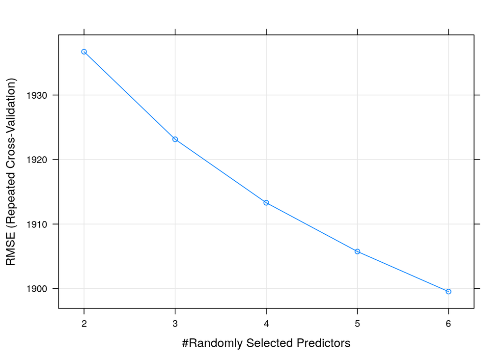

```r
startTimeModule <- proc.time()
set.seed(seedNum)
grid <- expand.grid(mtry = c(2,3,4,5,6))
fit.final1 <- train(targetVar~., data=Xy_train, method="rf", metric=metricTarget, tuneGrid=grid, trControl=control)
plot(fit.final1)
```

```r
print(fit.final1)
```

```
## Random Forest
##
## 36154 samples
##     6 predictor
##
## No pre-processing
## Resampling: Cross-Validated (10 fold, repeated 1 times)
## Summary of sample sizes: 32539, 32539, 32539, 32539, 32538, 32538, ...
## Resampling results across tuning parameters:
##
##   mtry  RMSE      Rsquared    MAE
##   2     1936.721  0.06547993  1691.533
##   3     1923.143  0.07219878  1675.369
##   4     1913.304  0.07785824  1662.927
##   5     1905.746  0.08315775  1653.258
##   6     1899.534  0.08783519  1644.855
##
## RMSE was used to select the optimal model using the smallest value.
## The final value used for the model was mtry = 6.
```

```r
proc.time()-startTimeModule
```

```
##     user   system  elapsed
## 1521.074   11.826 1536.277
```

```r
if (notifyStatus) email_notify(paste("Algorithm #1 tuning completed!",date()))
```

```
## [1] "Java-Object{org.apache.commons.mail.SimpleEmail@598067a5}"
```

```r
# Tuning algorithm #2 - Gradient Boosting
if (notifyStatus) email_notify(paste("Algorithm #2 tuning has begun!",date()))
```

```
## [1] "Java-Object{org.apache.commons.mail.SimpleEmail@4cf777e8}"
```

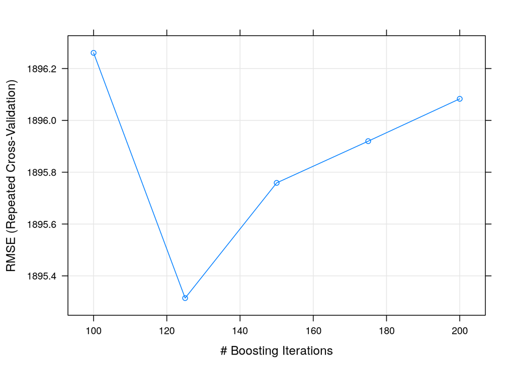

```r
startTimeModule <- proc.time()
set.seed(seedNum)
grid <- expand.grid(nrounds=c(100,125,150,175,200), max_depth=3, eta=0.4, gamma=0, colsample_bytree=0.8, min_child_weight=1, subsample=0.75)
fit.final2 <- train(targetVar~., data=Xy_train, method="xgbTree", metric=metricTarget, tuneGrid=grid, trControl=control, verbose=F)
plot(fit.final2)
```

```r
print(fit.final2)
```

[output not shown]

```r
proc.time()-startTimeModule
```

```
##    user  system elapsed
##  60.783   0.229  31.716
```

```r
if (notifyStatus) email_notify(paste("Algorithm #2 tuning completed!",date()))
```

```
## [1] "Java-Object{org.apache.commons.mail.SimpleEmail@3f49dace}"
```

### 5.d) Compare Algorithms After Tuning

```r
results <- resamples(list(RF=fit.final1, GBM=fit.final2))
summary(results)
```

```
##
## Call:
## summary.resamples(object = results)
##
## Models: RF, GBM
## Number of resamples: 10
##
## MAE
##         Min.  1st Qu.   Median     Mean  3rd Qu.     Max. NA's
## RF  1632.005 1638.601 1644.958 1644.855 1648.770 1664.172    0
## GBM 1610.563 1621.009 1625.928 1627.091 1631.583 1647.148    0
##
## RMSE
##         Min.  1st Qu.   Median     Mean  3rd Qu.     Max. NA's
## RF  1887.187 1893.463 1900.334 1899.534 1902.601 1916.291    0
## GBM 1881.462 1887.376 1893.355 1895.314 1898.587 1914.784    0
##
## Rsquared
##           Min.    1st Qu.     Median       Mean    3rd Qu.       Max. NA's
## RF  0.07629580 0.08222599 0.08883195 0.08783519 0.09261284 0.09767191    0
## GBM 0.06915149 0.08681825 0.08986090 0.08999815 0.09556869 0.10408699    0
```

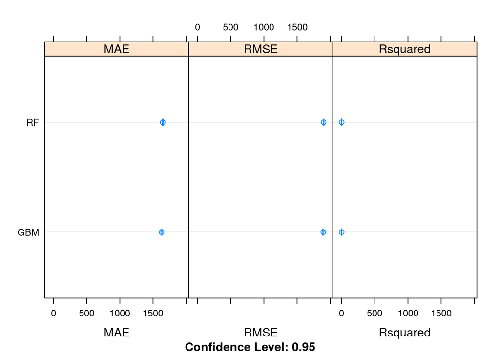

```r
dotplot(results)
```

## 6. Finalize Model and Present Results

Once we have narrow down to a model that we believe can make accurate predictions on unseen data, we are ready to finalize it. Finalizing a model may involve sub-tasks such as:

- Using an optimal model tuned to make predictions on unseen data.
- Creating a standalone model using the tuned parameters
- Saving an optimal model to file for later use.

```r
if (notifyStatus) email_notify(paste("Model Validation and Final Model Creation has begun!",date()))
```

```
## [1] "Java-Object{org.apache.commons.mail.SimpleEmail@56ef9176}"
```

### 6.a) Predictions on validation dataset

```r
predictions <- predict(fit.final1, newdata=Xy_test)
cat("The RMSE for the test data is:", RMSE(predictions, y_test),'\n')
```

```
## The RMSE for the test data is: 1905.878
```

```r
cat("The R2 score for the model is:", R2(predictions, y_test))
```

```
## The R2 score for the model is: 0.08382967
```

```r
predictions <- predict(fit.final2, newdata=Xy_test)
cat("The RMSE for the test data is:", RMSE(predictions, y_test),'\n')
```

```
## The RMSE for the test data is: 1899.256
```

```r
cat("The R2 score for the model is:", R2(predictions, y_test))
```

```
## The R2 score for the model is: 0.08859491
```

### 6.b) Create standalone model on entire training dataset

```r
startTimeModule <- proc.time()
set.seed(seedNum)
library(randomForest)
# Combining datasets to form a complete dataset that will be used to train the final model
Xy_complete <- rbind(Xy_train, Xy_test)

# finalModel <- randomForest(targetVar~., Xy_complete, mtry=6, na.action=na.omit)
# summary(finalModel)
proc.time()-startTimeModule
```

```
##    user  system elapsed
##   0.030   0.001   0.032
```

### 6.c) Save model for later use

```r
#saveRDS(finalModel, "./finalModel_Regression.rds")
```

```r
if (notifyStatus) email_notify(paste("Model Validation and Final Model Creation Completed!",date()))
```

```
## [1] "Java-Object{org.apache.commons.mail.SimpleEmail@5649fd9b}"
```

```r
proc.time()-startTimeScript
```

```
##     user   system  elapsed
## 27634.10    80.99 27211.20
```